# The President’s Covid-19 Network

Ansgar Wolsing

Oct 7th, 2020

## Background

On Friday, Oct 2nd, alleged tax evader TV celebrity US President Donald Trump announced he got tested positive for Covid-19. In the days leading up to this announcement, Trump met lots of people ignoring any guidelines how to prevent spreading the virus. So let’s revisit whom the Superspreader in Chief Trump encountered in the week before he announced he had contracted Covid-19.

```r
library(tidyverse)
library(lubridate)
library(ggtext)
library(ggraph)
library(tidygraph)

source("02_graphs_setup.R", verbose = FALSE)
```

## Scrape information

The New York Times has published an [article](https://www.nytimes.com/interactive/2020/10/02/us/politics/trump-contact-tracing-covid.html) with great visualization of the events Donald Trump participated before his positive Covid-19 test result was announced.

Let’s scrape Trump’s contacts at events from the article using `rvest` package and put everything into a tibble holding details about the meetings.

```r
library(rvest)

# read the HTML content of the NYT article
url <- "https://www.nytimes.com/interactive/2020/10/02/us/politics/trump-contact-tracing-covid.html"
page <- read_html(url)

# extract days nodes
days <- html_nodes(page, css = ".g-day")

# extract the dates
day_names <- html_nodes(days, css = ".g-daySubHead") %>%
  html_text()

# get the number of meetings for each day
meetings_each_day <- map(days, ~html_nodes(.x, css = ".g-meeting")) %>%
  map_dbl(length)
names(meetings_each_day) <- day_names

# expand the day names vector by the number of meetings for each day,
# so that 1 meeting is 1 row
day_names_expanded <- rep(day_names, meetings_each_day)

# extract meetings
meeting_nodes <- html_nodes(days, css = ".g-meeting")

# extract meeting names
meeting_names <- map_chr(meeting_nodes, ~html_nodes(.x, css = ".g-meetingSubhead") %>%
                           html_text())

# tibble of meetings with meeting name and date to begin with
meetings <- tibble(meeting = meeting_names,
                   date_str = day_names_expanded)

meetings <- meetings %>%
  mutate(wday = str_match(date_str, "(\\w+),")[, 2],
         date = str_match(date_str, ",\\s(.+)")[, 2])

# extract information for persons attending meetings
extract_contacts <- function(meeting) {
  person_nodes <- html_nodes(meeting, css = ".g-personStatus")
  person_names <- html_nodes(person_nodes, css = ".g-personName") %>%
    html_text()
  person_covid_status <- html_nodes(person_nodes, css = ".g-personMug") %>%
    html_attr("class") %>%
    str_extract("test-(positive|negative)")

  tibble(person_name = person_names, person_covid_status)
}

# apply extraction to all person lists
meetings_persons <- map(meeting_nodes, extract_contacts)

# add persons to meetings tibble
meetings <- meetings %>%
  bind_cols(tibble(persons = meetings_persons))

# clean up person data
meetings <- meetings %>%
  # unnest(persons) %>%
  mutate(persons = map(
    persons,
    ~ mutate(.x,
      # cleanup person names by adding whitespaces where br tags were in the HTML
      person_name = str_replace_all(person_name,
                                    "([a-z]|\\.)([A-Z])",
                                    "\\1 \\2"),
      # cleanup covid status
      person_covid_status = case_when(
        person_covid_status == "test-positive" ~ "positive",
        person_covid_status == "test-negative" ~ "negative",
        is.na(person_covid_status) ~ "unknown"
      ) %>% as_factor()
    )
  ))

# store results with a timestamp in the filename
ts_str <- format(Sys.time(), "%Y%m%d-%H%M%S")
write_rds(meetings,
          glue::glue("../output/trump_covid_tracing/trump_covid_tracing_meetings_{ts_str}.RData"))
```

## Prepare the graph

Before building a graph of all contacts of Donald Trump prior to his Covid-19 announcement, we create all unique combinations of persons in the persons tibble for each meeting. The `combn` function from the `utils` package comes in handy. `combn` generates combinatons of the elements of a vector taken `m` elements at a time. The output is matrix (with `simplify = TRUE`), which has to be transposed with `t`. I wrap the call of `combn` in a mapper function which is than applied to each element of the persons lists.

```r
# remove meetings with no persons listed
meetings <- meetings %>%
  filter(map(persons, nrow) > 0)

# Build a tibble with all combinations of persons
build_connections <- function(x) {
  combn(x$person_name, 2) %>%
    t() %>%
    as_tibble() %>%
    rename(person1 = V1, person2 = V2)
}

# map(meetings$persons, afunc)
meetings <- meetings %>%
  mutate(person_connections = map(persons, build_connections))

# Covid status for all persons consolidated
person_covid_status <- meetings$persons %>%
  bind_rows() %>%
  distinct()

# Weighted connections
connections <- meetings$person_connections %>%
  bind_rows() %>%
  count(person1, person2, name = "weight", sort = TRUE)

# Attendents Rose Garden meeting
rose_garden_attendants <- meetings %>%
  filter(meeting == "Rose Garden nomination ceremony for Amy Coney Barrett") %>%
  unnest(persons) %>%
  pull(person_name)

# create undirected graph from connections
graph <- as_tbl_graph(connections, directed = FALSE) %>%
  activate(nodes) %>%
  inner_join(person_covid_status, by = c("name" = "person_name")) %>%
  mutate(rose_garden_attendant = (name %in% rose_garden_attendants)) %>%
  mutate(centrality = centrality_degree())
```

## Meetings

Let’s take a look how many people were tested positive on Covid-19 after having attended the meetings. Turns out many people attended the Rose Garden nomination ceremony for Amy Coney Barrett.

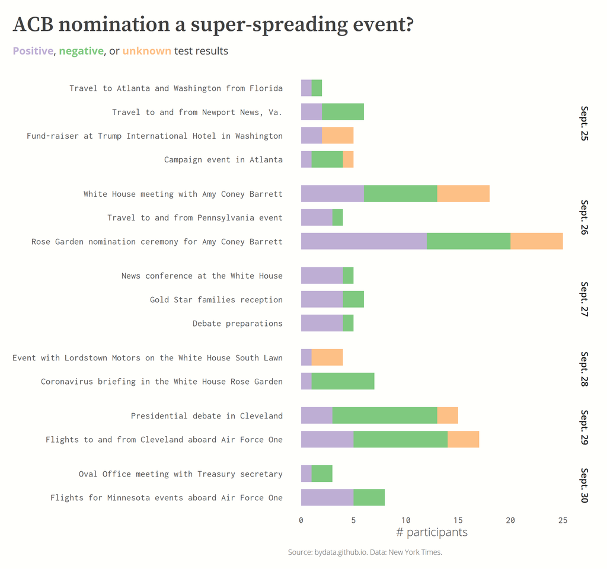

```r
# colors for Covid test results
colors <- RColorBrewer::brewer.pal(3, "Accent")
names(colors) <- c("negative", "positive", "unknown")

plot_subtitle <- sprintf("<b style='color:%s'>Positive</b>, <b style='color:%s'>negative</b>,
                         or <b style='color:%s'>unknown</b> test results",
                          colors["positive"], colors["negative"], colors["unknown"])

plot_caption <- "Source: bydata.github.io. Data: New York Times."

meetings %>%
  select(meeting, persons, date) %>%
  unnest(persons) %>%
  ggplot(aes(meeting)) +
  geom_bar(aes(fill = fct_rev(person_covid_status)),
           width = 0.7,
           position = "stack",
           show.legend = FALSE) +
  scale_fill_manual(values = colors) +
  coord_flip() +
  facet_grid(rows = vars(date), scales = "free_y", space = "free") +
  labs(title = "ACB nomination a super-spreading event?",
       subtitle = plot_subtitle,
       caption = plot_caption,
       x = NULL, y = "# participants")
```

## Network of contacts visualized

Let’s plot the network of contacts and highlight all attendants of the Rose Garden nomination ceremony.

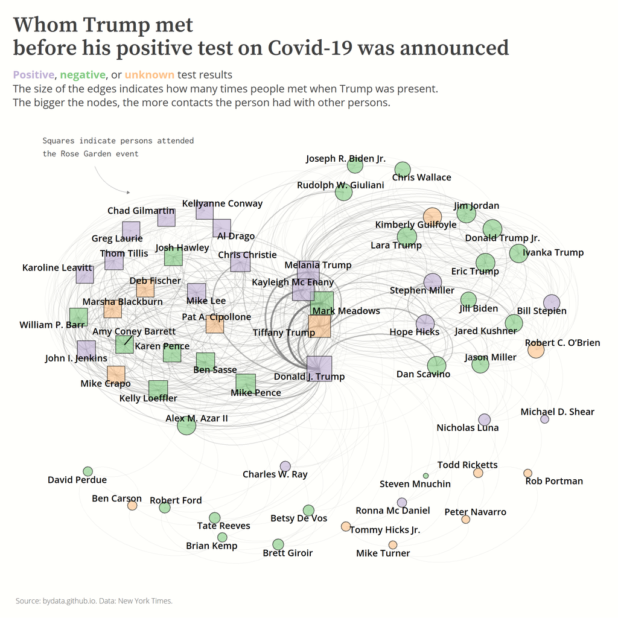

```r
plot_subtitle <- sprintf("<b style='color:%s'>Positive</b>, <b style='color:%s'>negative</b>,
                          or <b style='color:%s'>unknown</b> test results<br>
                         The size of the edges indicates how many times people met when Trump was present.<br>
                         The bigger the nodes, the more contacts the person had with other persons.",
                          colors["positive"], colors["negative"], colors["unknown"])

set.seed(1234)
graph %>%
  ggraph(layout = "stress") +
  geom_edge_arc(aes(width = weight, edge_alpha = weight), edge_color = "grey50",
                 show.legend = FALSE) +
  geom_node_point(aes(size = centrality,
                      fill = person_covid_status,
                      shape = rose_garden_attendant),
                  alpha = 0.6,
                 show.legend = FALSE) +
  geom_node_text(aes(label = name), repel = TRUE,
                 family = "Open Sans SemiBold",
                 size = 3,
                 show.legend = FALSE
                 ) +
  annotate("text", x  = -1.5, y = 1.5,
           hjust = 0, col = "grey25", family = "Inconsolata",
           label = "Squares indicate persons attended\nthe Rose Garden event",
           size = 3) +
  geom_curve(aes(x = -1.2, xend = -1, y = 1.35, yend = 1.15),
             curvature = 0.3, col = "grey50", size = 0.2,
             arrow = arrow(type = "closed", length = unit(1, "mm"))) +
  scale_edge_width(range = c(0.25, 1)) +
  scale_size(range = c(2, 12)) +
  scale_fill_manual(values = colors) +
  scale_shape_manual(values = c("TRUE" = 22, "FALSE" = 21)) +
  labs(title = "Whom Trump met\nbefore his positive test on Covid-19 was announced",
       subtitle = plot_subtitle,
       caption = plot_caption
       ) +
  # theme_bw() +
  theme(legend.position = "top",
        legend.justification = "left",
        plot.title = element_text(family = "Source Serif Pro SemiBold"))
```

Disclaimer: This exercise is completely unscientific. I’m neither an epidemiologist nor virologist. It’s just some pet project scraping and data visualization.